# TP 2 - correction

Outils de surveillance et analyses statistiques

INTECHMER - CT3 GEM

## Données Planctons

On peut représenter les points de collecte de données sur une carte à l’aide du code suivant :

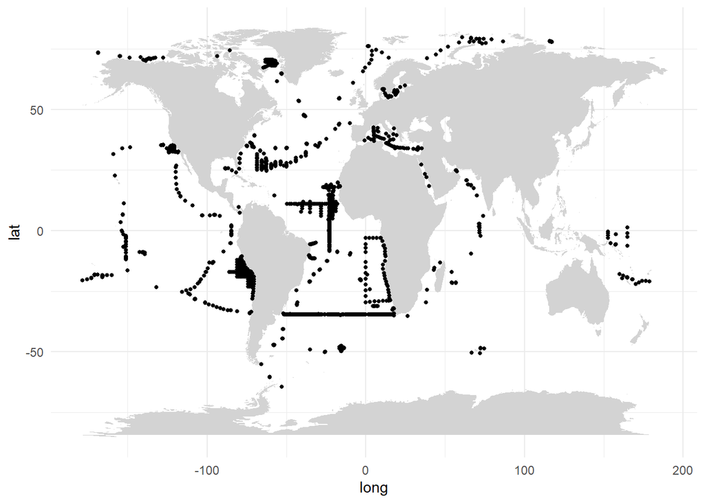

## En considérant les données brutes

### Décrire les données, en particulier de concentrations

On remarque que les concentrations sont très proches de 0, avec beaucoup de valeurs *aberrantes*/*outliers*. Il faut donc envisager de faire une transformation sur celles-ci pour pouvoir les étudier. Plusieurs possibilités :

- Transformer en variable binaire : présence / absence
- Faire des intervalles : aucun / peu / … / beaucoup
- Opérer une transformation mathématique :
  - Division par le total ou par le maximum
  - Normalisation pour que la somme en ligne soit égale à 1
  - Utiliser les rangs
  - Standardisation des variables
  - Transformation de Hellinger
    $$y\prime_i^j = \sqrt{\frac{y_i^j}{\sum_k y_i^k}}$$
  - Plusieurs autres possibles…

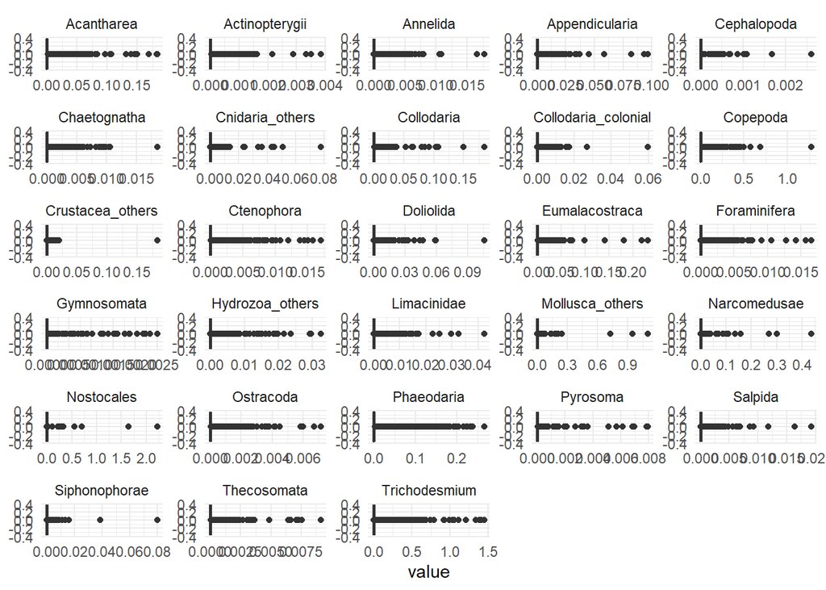

### Effectuer une transformation de Hellinger sur les données de concentrations

On utilise donc la fonction `decostand()` du package `vegan`.

Les concentrations sont un peu *mieux* réparties.

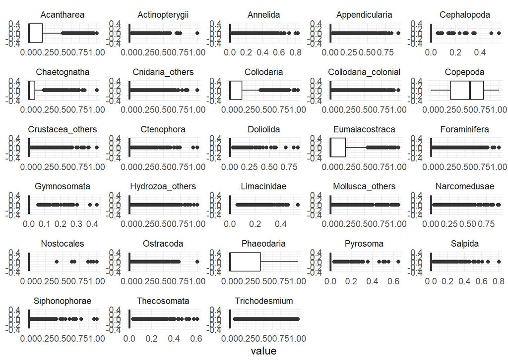

### Faire quelques traitements sur les variables explicatives

1. Remplacer les données manquantes par la valeur moyenne de la variable
2. Transformer les variables `bulk_conc` et `snow_conc` en calculant $\log(1+x)$ (car valeurs parfois égales à 0)
3. Normaliser toutes les variables

Ces trois opérations sont réalisables en un code

### Couche épipélagique

#### Réaliser une ACP sur les concentrations

On ajoute donc les variables explicatives en variables supplémentaires (cf paramètre `quanti.sup` dans la fonction `PCA()`).

|  | eigenvalue | percentage of variance | cumulative percentage of variance |
| --- | --- | --- | --- |
| comp 1 | 0.15 | 26.43 | 26.43 |
| comp 2 | 0.09 | 15.34 | 41.77 |
| comp 3 | 0.05 | 9.48 | 51.25 |
| comp 4 | 0.04 | 7.83 | 59.07 |
| comp 5 | 0.03 | 6.05 | 65.12 |
| comp 6 | 0.03 | 5.78 | 70.90 |
| comp 7 | 0.03 | 4.93 | 75.83 |
| comp 8 | 0.02 | 3.11 | 78.94 |
| comp 9 | 0.01 | 2.48 | 81.42 |
| comp 10 | 0.01 | 2.35 | 83.77 |

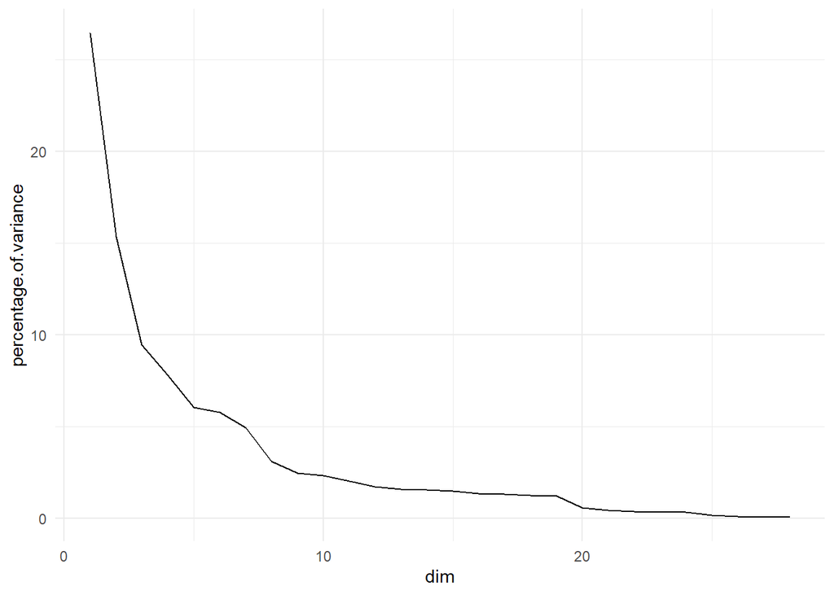

La représentation via la fonction `plot()` est difficilement exploitable.

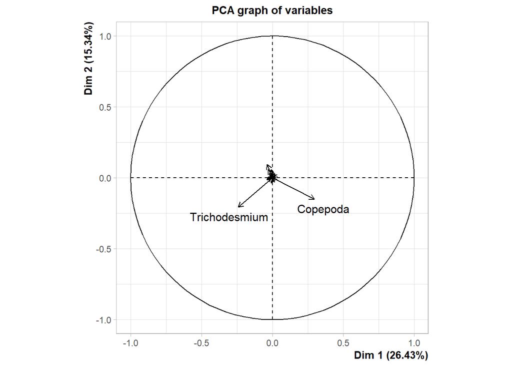

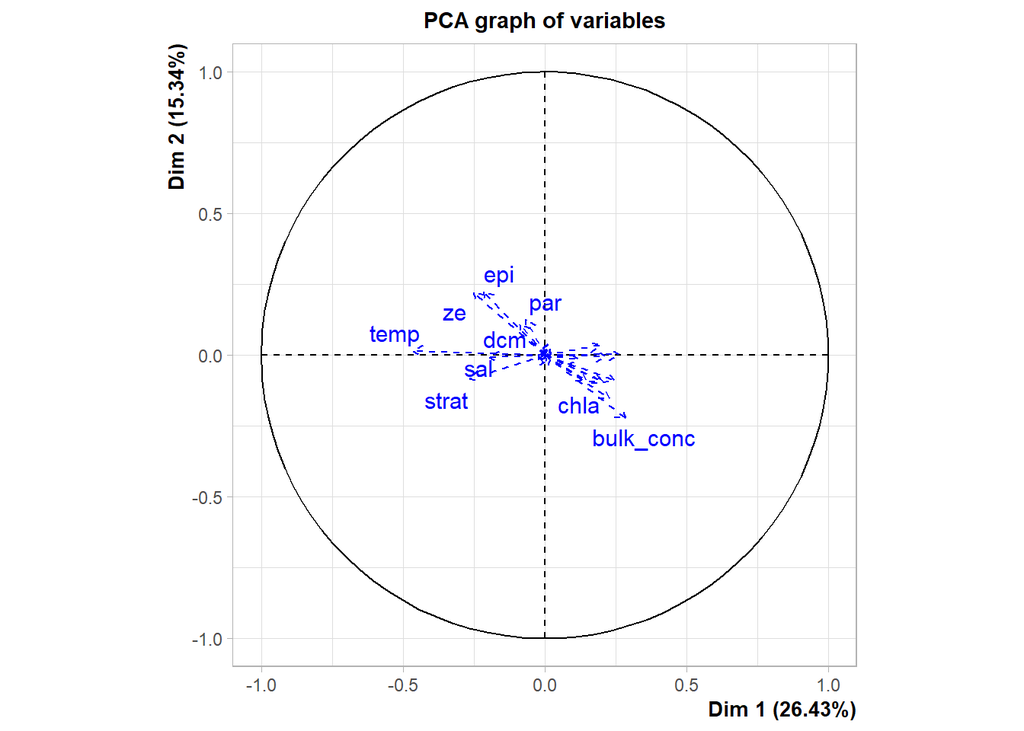

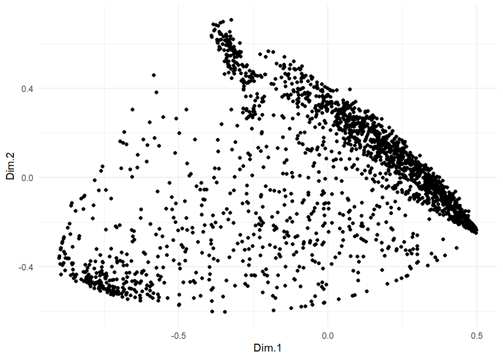

#### Rechercher un nombre de classes avec une CAH (en utilisant la distance euclidienne et la méthode de *Ward*)

On choisit donc 3 classes.

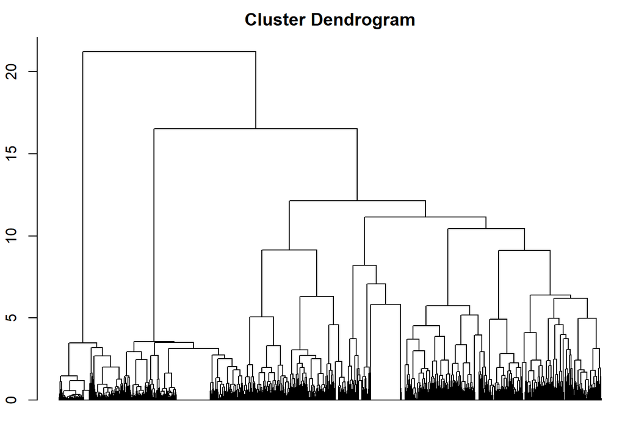

#### Rechercher la partition optimale à l’aide de $k$-means

#### Décrire les classes à partir des données de concentrations

Voici les 3 classes qu’on trouve :

- Forte valeur sur *Copepoda*
- Légèrement élevé sur *Collodaria* et *Acantharea*
- Forte concentration sur *Trichodesmium*

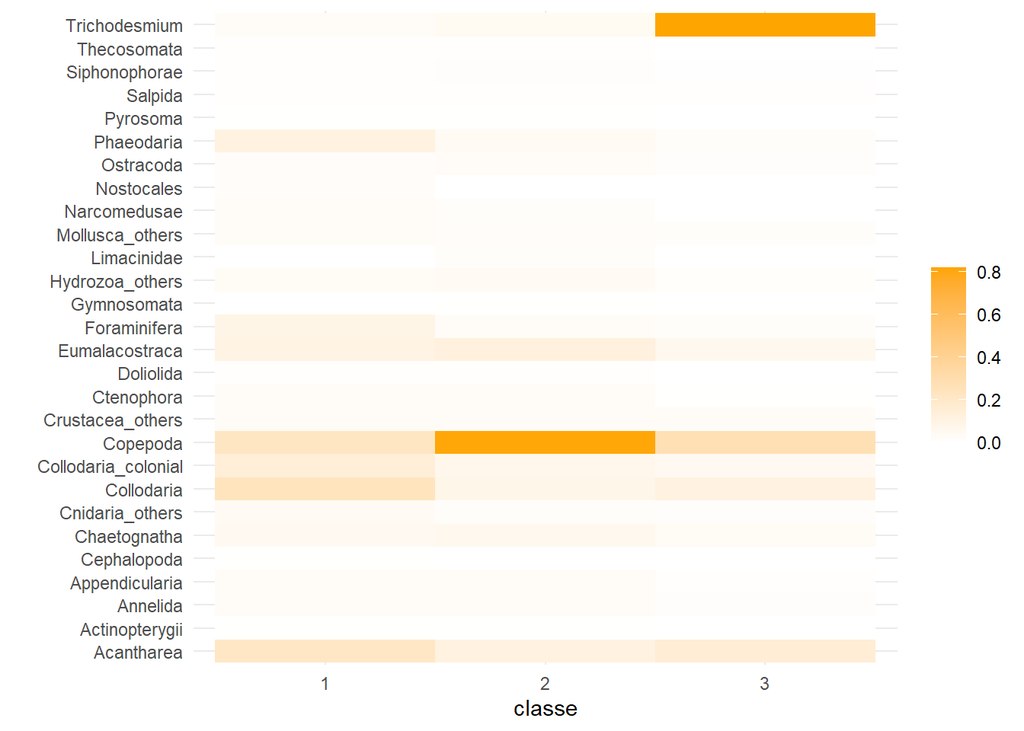

#### Représenter la partition sur le plan factoriel

- Classe *Copepoda* liée à `bulk_conc` et `chla`
- Classe *Collodaria* et *Acantharea* liée à `ze` et `epi`
- Classe *Trichodesmium* liée à `temp` et `strat`

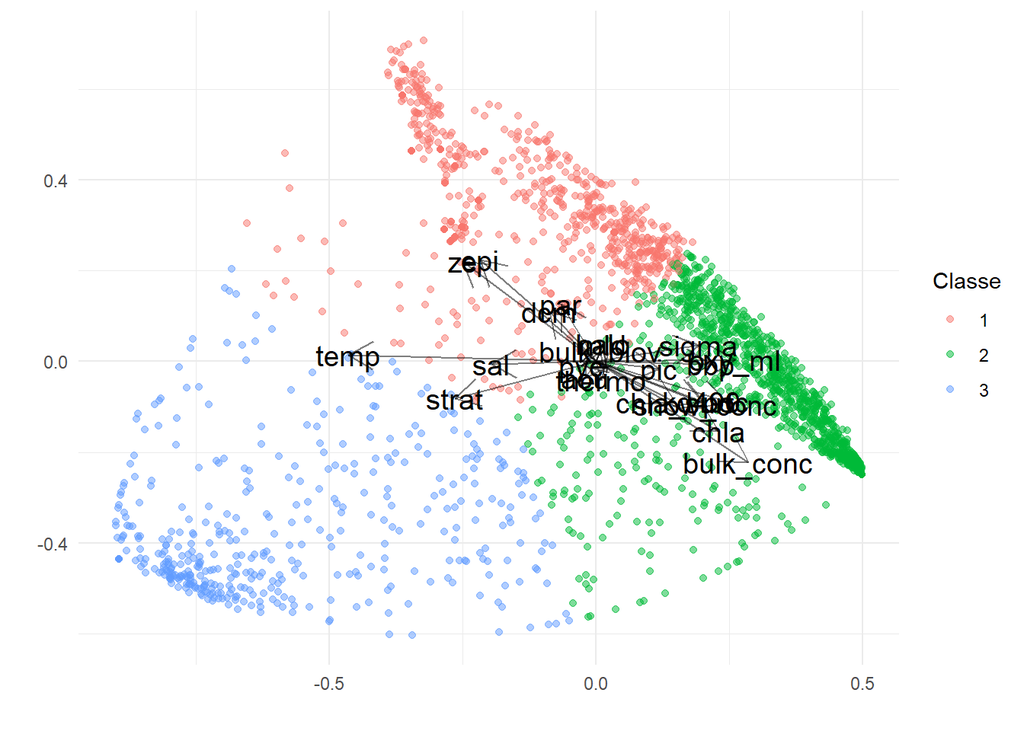

#### Représenter la partition sur une carte

Difficile de bien distinguer sur ce graphique

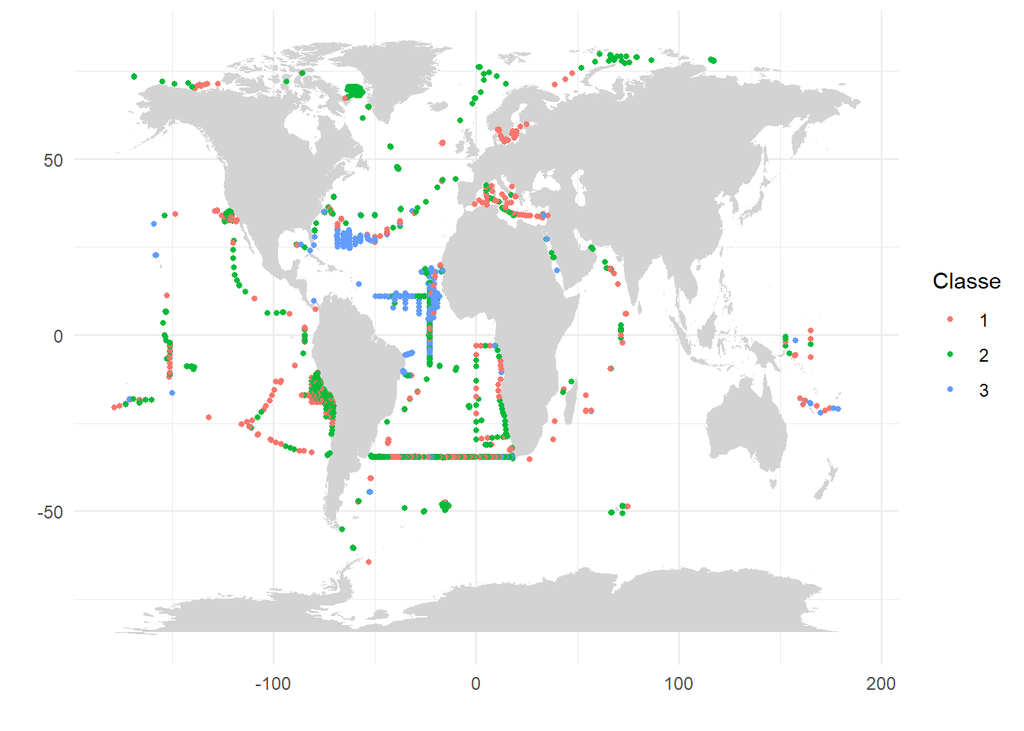

- Classe *Copepoda* plus présent vers le pôle Nord et le pôle Sud que les autres
- Classe *Collodaria* et *Acantharea* un peu partout
- Classe *Trichodesmium* dans les latitudes autour de l’équateur

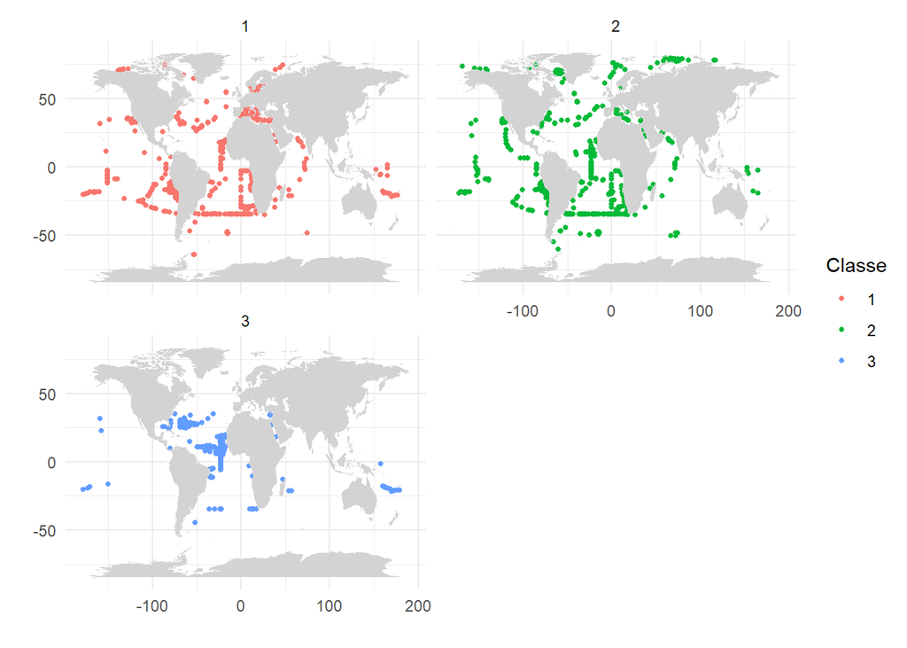

### Couche mésopélagique supérieure

#### Réaliser une ACP sur les concentrations

On ajoute donc les variables explicatives en variables supplémentaires (cf paramètre `quanti.sup` dans la fonction `PCA()`).

Les deux premières composantes expliquent 39% de variance.

|  | eigenvalue | percentage of variance | cumulative percentage of variance |
| --- | --- | --- | --- |
| comp 1 | 0.10 | 22.59 | 22.59 |
| comp 2 | 0.07 | 17.04 | 39.64 |
| comp 3 | 0.04 | 9.30 | 48.93 |
| comp 4 | 0.03 | 6.92 | 55.85 |
| comp 5 | 0.03 | 6.29 | 62.14 |
| comp 6 | 0.03 | 5.88 | 68.02 |
| comp 7 | 0.02 | 4.53 | 72.55 |
| comp 8 | 0.02 | 4.15 | 76.71 |
| comp 9 | 0.02 | 3.70 | 80.41 |
| comp 10 | 0.02 | 3.59 | 84.00 |

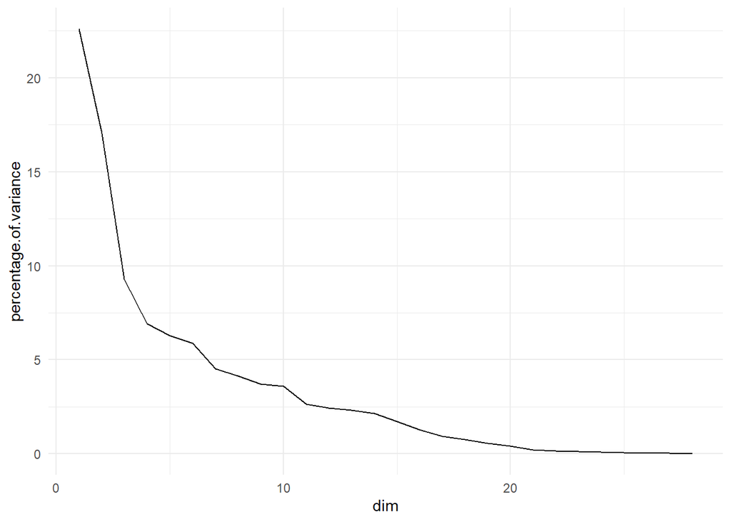

La représentation via la fonction `plot()` est difficilement exploitable.

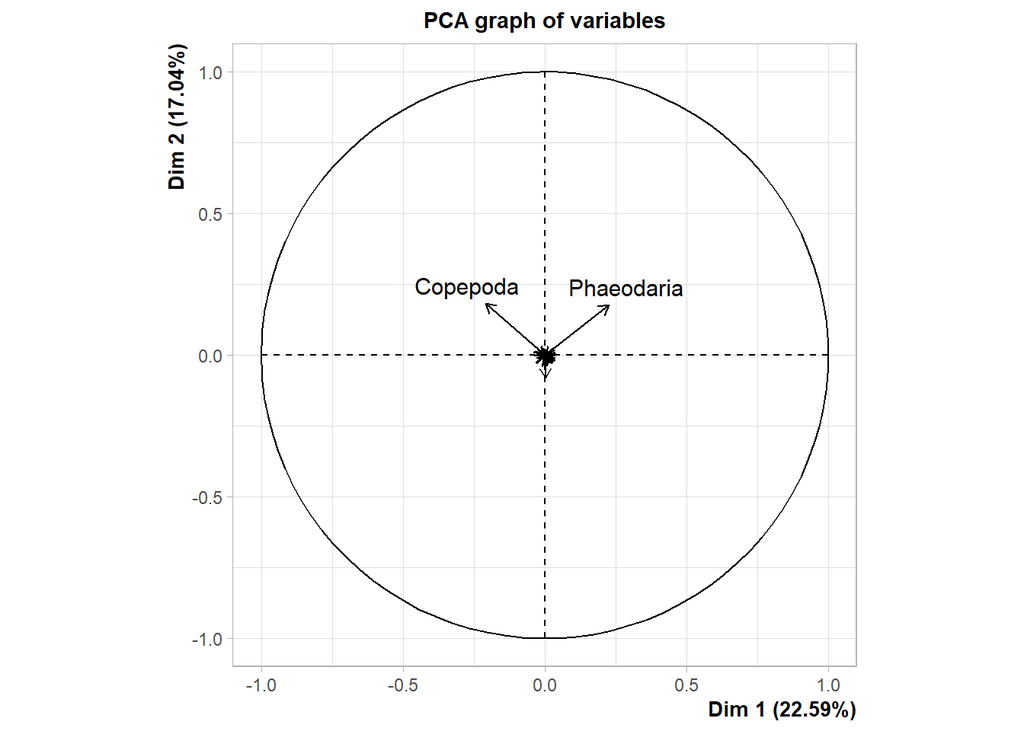

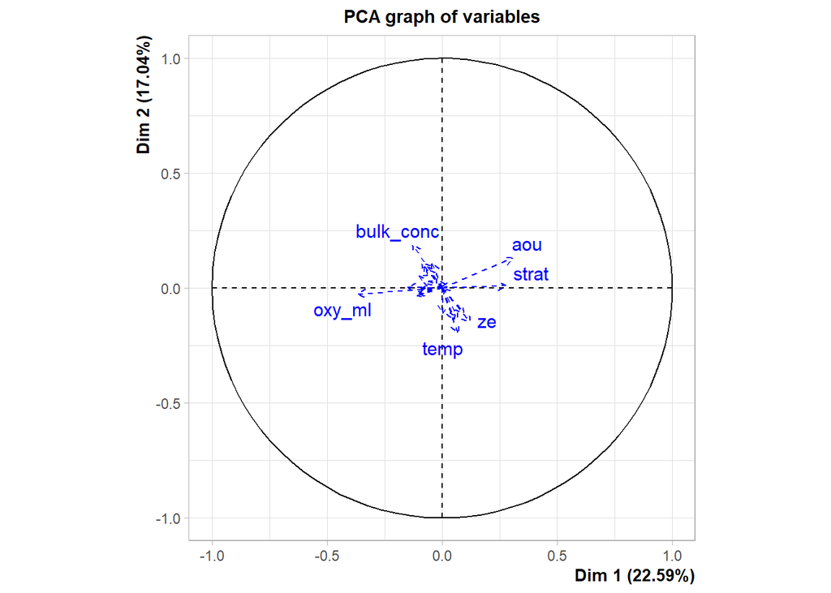

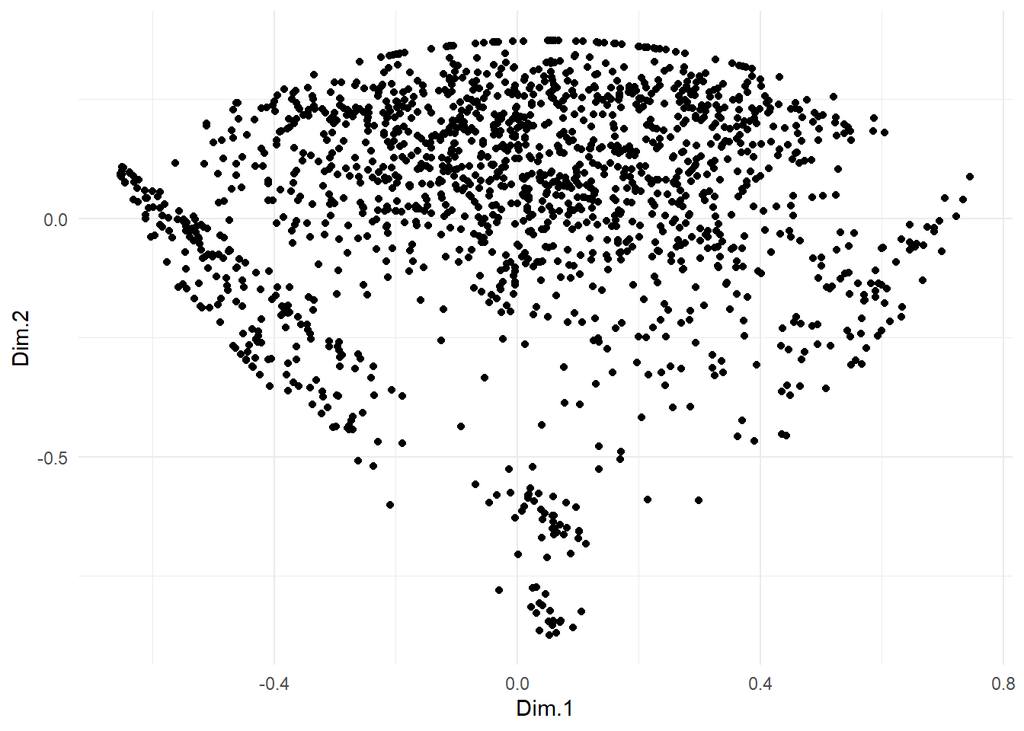

#### Rechercher un nombre de classes avec une CAH (en utilisant la distance euclidienne et la méthode de *Ward*)

On choisit donc 3 classes.

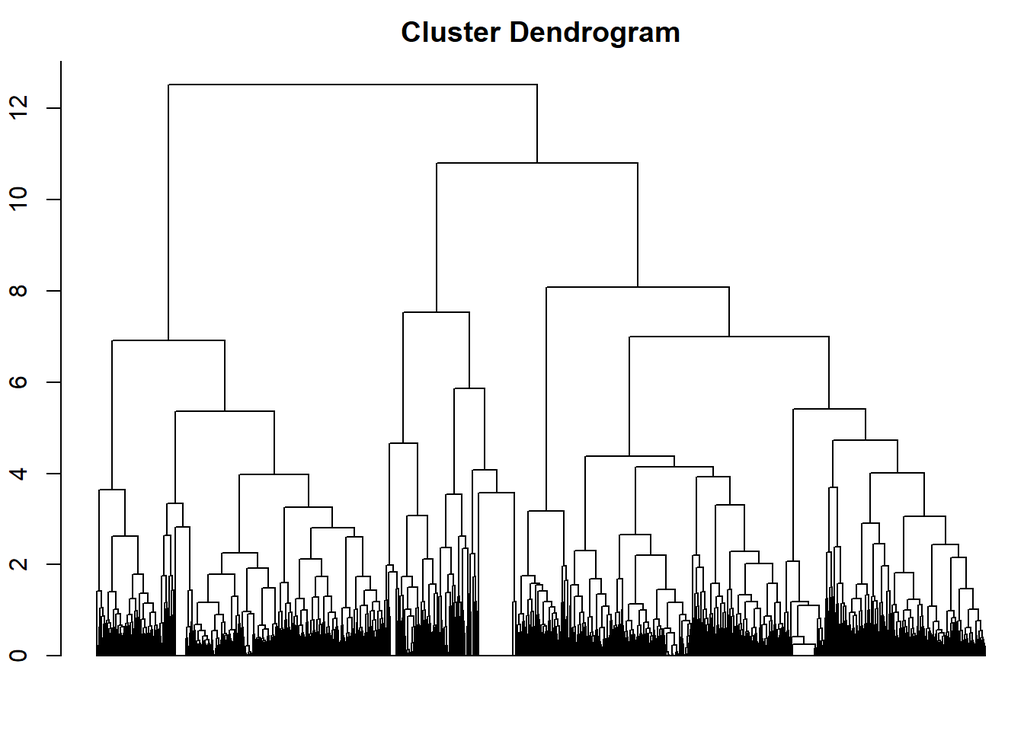

#### Rechercher la partition optimale à l’aide de $k$-means

#### Décrire les classes à partir des données de concentrations

Voici les 3 classes qu’on trouve :

- Forte valeur sur *Phaeodaria*
- Légèrement élevé sur *Eumalacostraca*
- Forte concentration sur *Copepoda*

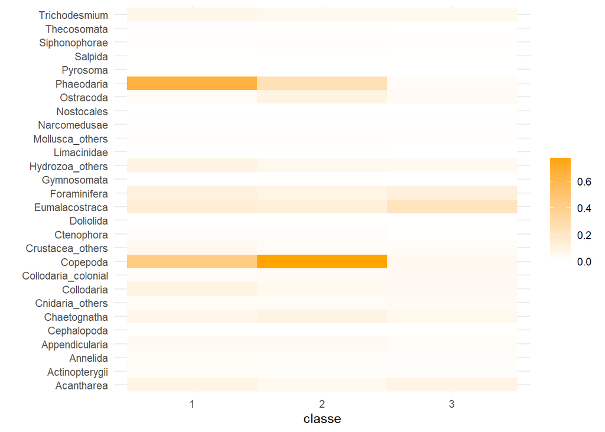

#### Représenter la partition sur le plan factoriel

- Classe *Phaeodaria* liée à `aou` et `strat`
- Classe *Eumalacostraca* liée aucune variable
- Classe *Copepoda* liée à `oxy_ml`

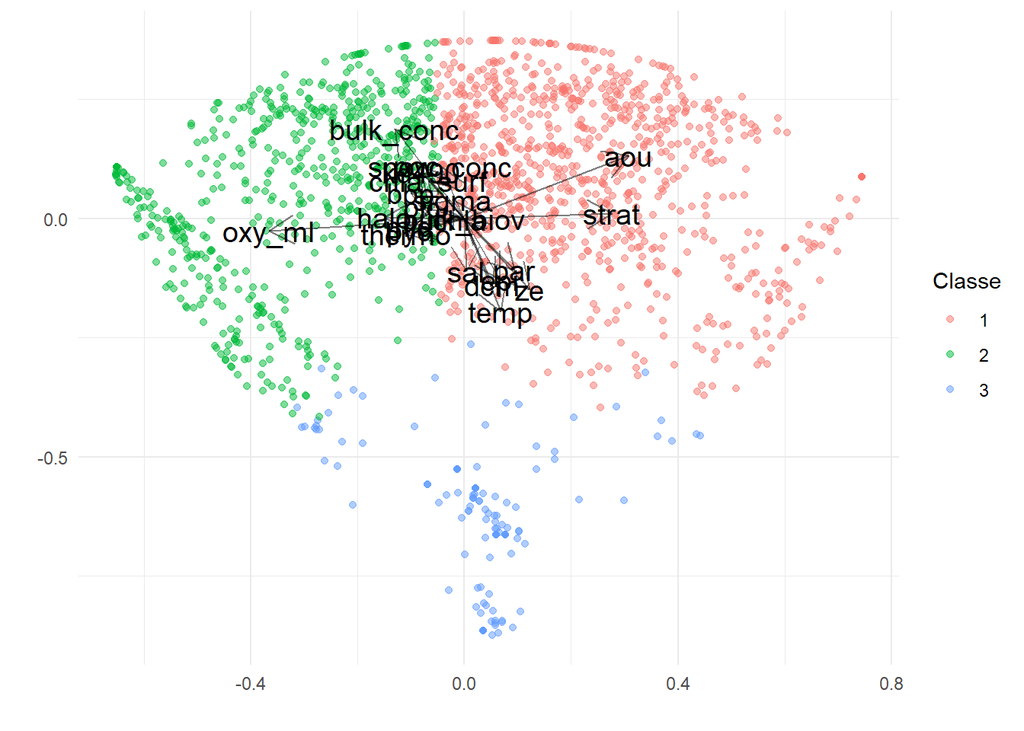

#### Représenter la partition sur une carte

Difficile de bien distinguer sur ce graphique

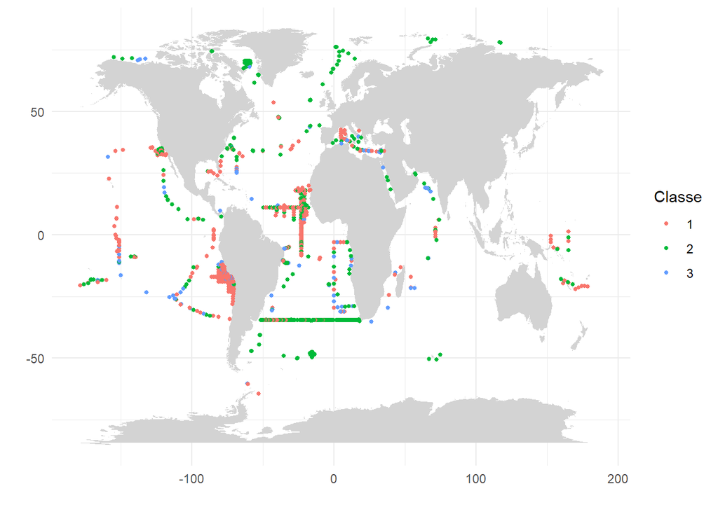

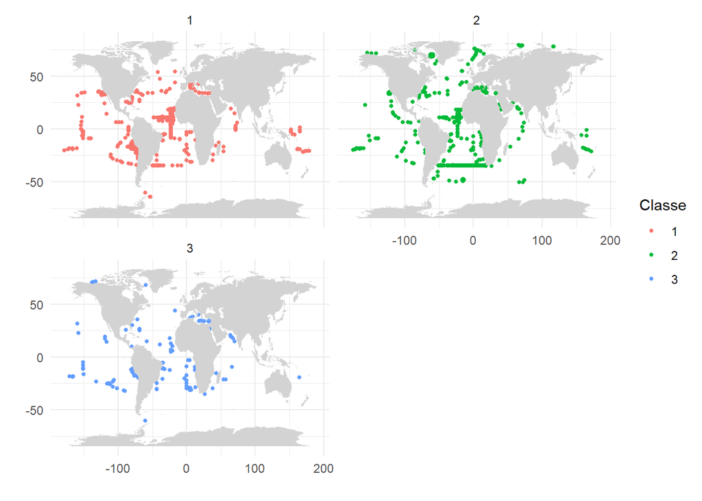

## En binarisant les variables

On constate que le plancton *Copepoda* est particulièrement présent.

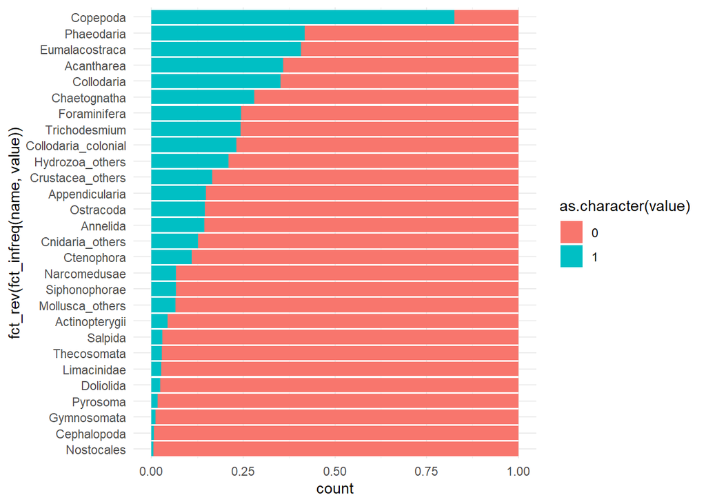

### Couche épipélagique

#### Recherche d’une partition à l’aide de la CAH

En utilisant le critère de Ward plutôt que le lien simple, on va choisir ici 4 classes.

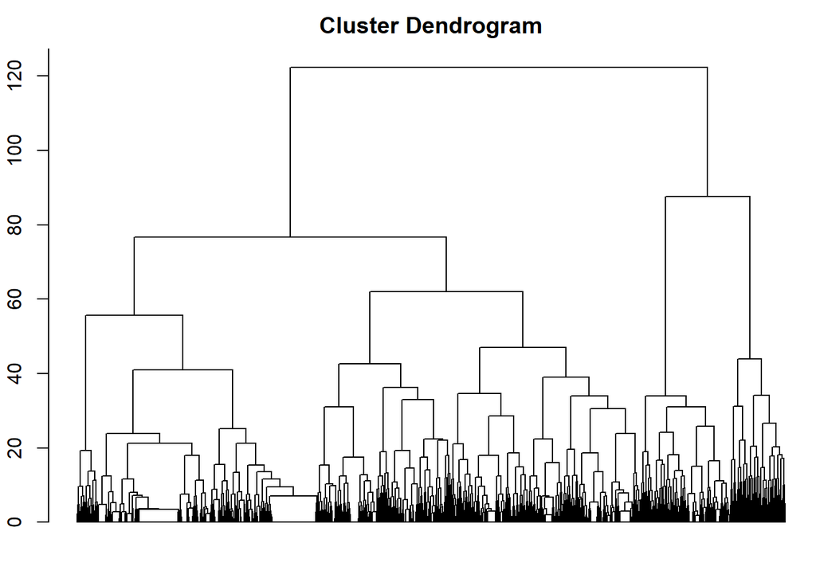

#### Classes obtenues

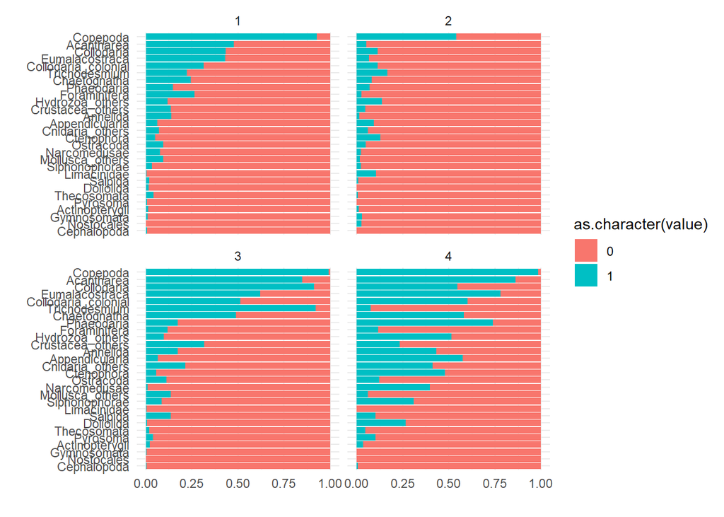

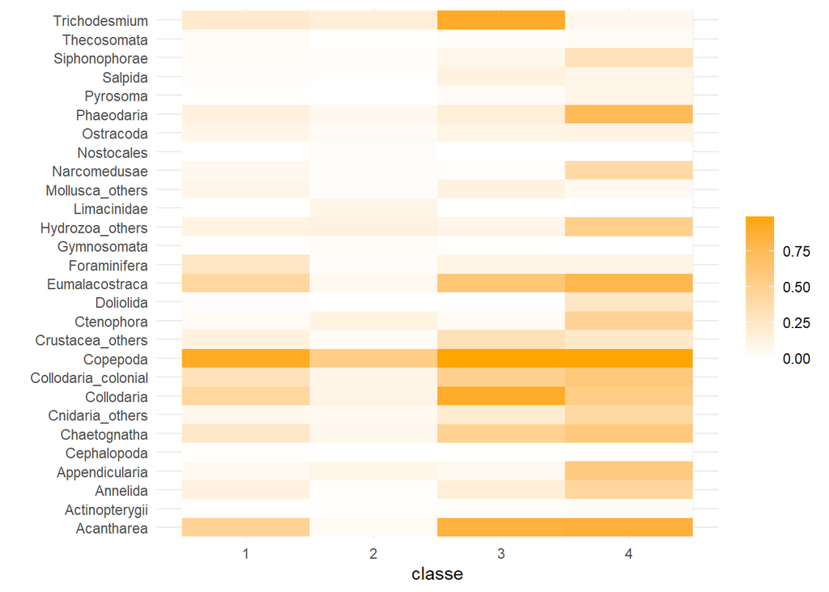

Les partitions ne semblent pas être correspondre entre les deux méthodes.

| 1 | 2 | 3 | 4 |
| --- | --- | --- | --- |
| 387 | 347 | 46 | 69 |
| 622 | 401 | 79 | 119 |
| 141 | 107 | 191 | 8 |

### Couche mésopélagique

#### Recherche d’une partition à l’aide de la CAH

En utilisant le critère de Ward plutôt que le lien simple, on va choisir ici 4 classes.

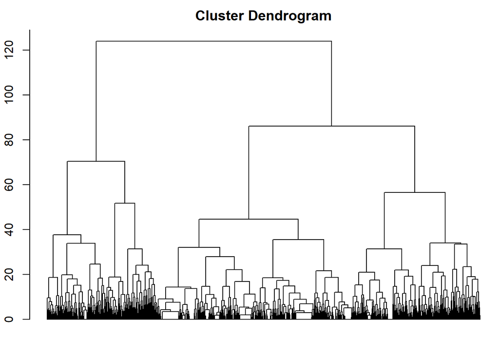

#### Classes obtenues

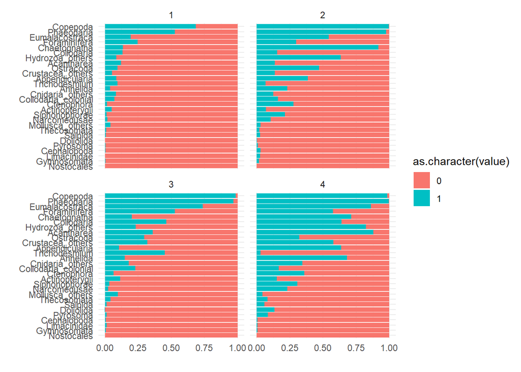

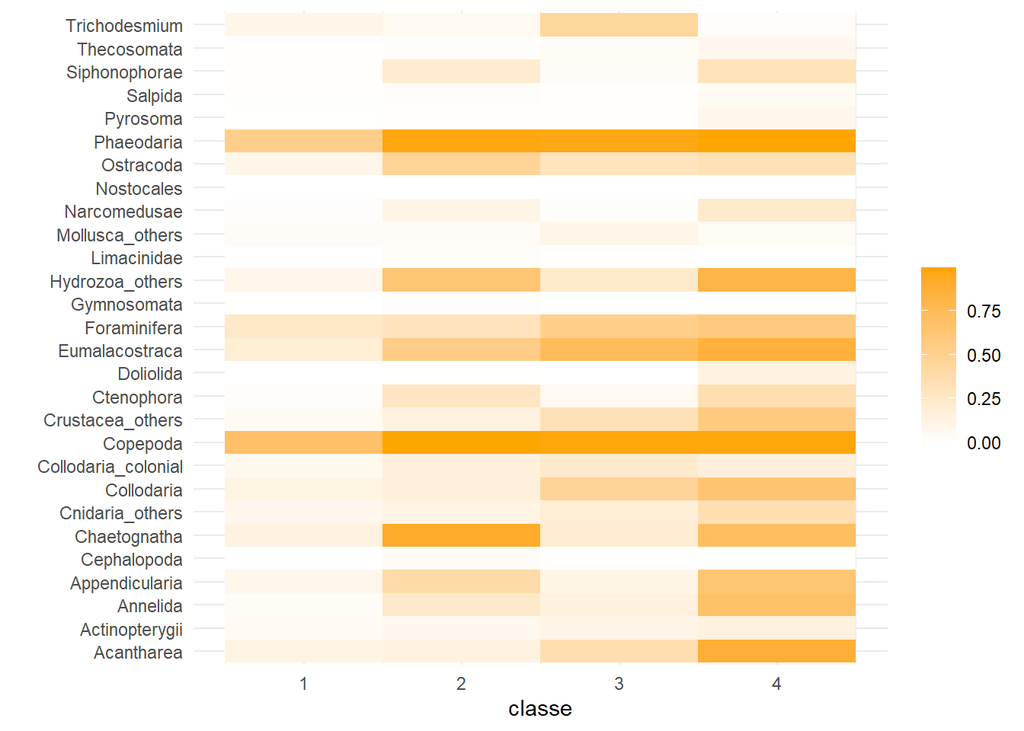

Ici non plus, les partitions ne semblent pas être correspondre entre les deux méthodes.

| 1 | 2 | 3 | 4 |
| --- | --- | --- | --- |
| 306 | 107 | 324 | 155 |
| 307 | 128 | 179 | 46 |
| 171 | 3 | 13 | 8 |